# Factors influencing Turkiye’s Growth

Fei Wu, Merve Onal, Siyao Chen, Ye Khaung Oo

2024-04-23

# Rationale and Research Questions

How does GDP growth relate to investment growth, capital accumulation and population growth in Turkiye from 1999-2022 period? Does electricity consumption have any relationship with GDP, investment and population?

## Sub-Questions:

Has electricity consumption increased with GDP growth during the period from 1999 to 2022 in Turkiye? Have electricity consumption increased with investment and population growth during the period from 1999 to 2022 in Turkiye?Is there a quantifiable impact of electricity consumption on GDP growth in Turkiye, when considering the effects of investment and population growth?

# Background

We have analyzed the impact of investment growth, population growth and electricity consumption on the GDP growth of Turkiye for the period of 1999-2022. We obtained a dataset from Turkiye and recorded the data points as log growth points. Our aim is to explore the interdependencies between critical economic indicators that influence Turkiye’s economic landscape over a significant period. By examining the correlations among these variables, we aim to understand how each one potentially impacts or correlates with the others, particularly in terms of GDP growth. Our analysis seeks to scrutinize the interactions between GDP growth and key growth indicators such as population, investment and electricity consumption to illuminate the intertwined influences of these variables from 1999 to 2022.

## Significance

Understanding the relationship between electricity consumption and GDP growth is crucial for improving stable economic growth and development. It is important to understand the behavior of electricity consumption in relation to the economy. This understanding is essential for developing informed economic policies and investment strategies. By identifying the strength and direction of these relationships, policymakers and economists can better predict future trends and make decisions that aim to foster economic stability and growth. Grasping the dynamics between electricity consumption and GDP growth is essential for strategies that underpin economic stability and advancement. These findings reinforce the importance of electricity in bolstering economic development, as noted by Kasperowicz (2014).

## Theoretical Context

The central hypothesis of this research is that an increase in electricity consumption is linked to GDP growth. This hypothesis is based on the understanding that investment, population, and electricity consumption are key factors that contribute to GDP growth. The hypothesis for this analysis suggests that there are significant correlations between GDP growth and other important economic indicators such as population growth, investment growth, and electricity consumption. By analyzing these correlations, we can verify the interconnectedness of these variables and determine whether they support or refute prevailing economic theories about their interactions. The hypothesis central to this analysis posits that rising electricity consumption acts as a catalyst for GDP growth. This supposition is based on the idea that investment, demographic changes, and energy consumption together help explain the narrative of GDP growth.

## Dataset Information

This analysis uses three databases: (https://ytbsbilgi.teias.gov.tr/ytbsbilgi/frm_istatistikler.jsf) for electricity consumption; (https://data.tuik.gov.tr/Kategori/GetKategori?p=ulusal-hesaplar-113&dil=2) for GDP growth rate; (https://databank.worldbank.org/source/world-development-indicators) for investment and population growth. The Solow–Swan model or exogenous growth model is an economic model of long-run economic growth. It attempts to explain long-run economic growth by looking at capital accumulation, labor or population growth, and productivity increases largely driven by technological progress. In our analysis, parallel with Solow-Swan model we assume that the production function takes the following form: Y = aKbL1-b where 0 < b < 1. The production function is known as the Cobb-Douglas Production function, which is the most widely used neoclassical production function. We analyze the effect of investment growth which corresponds to capital accumulation and population growth on the GDP growth of Turkiye for the 1999-2022 period. We also analyze the impact of electricity consumption on the GDP growth. For details of each database, please refer to the files in the Metadata folder under the Data folder.

# Exploratory Analysis

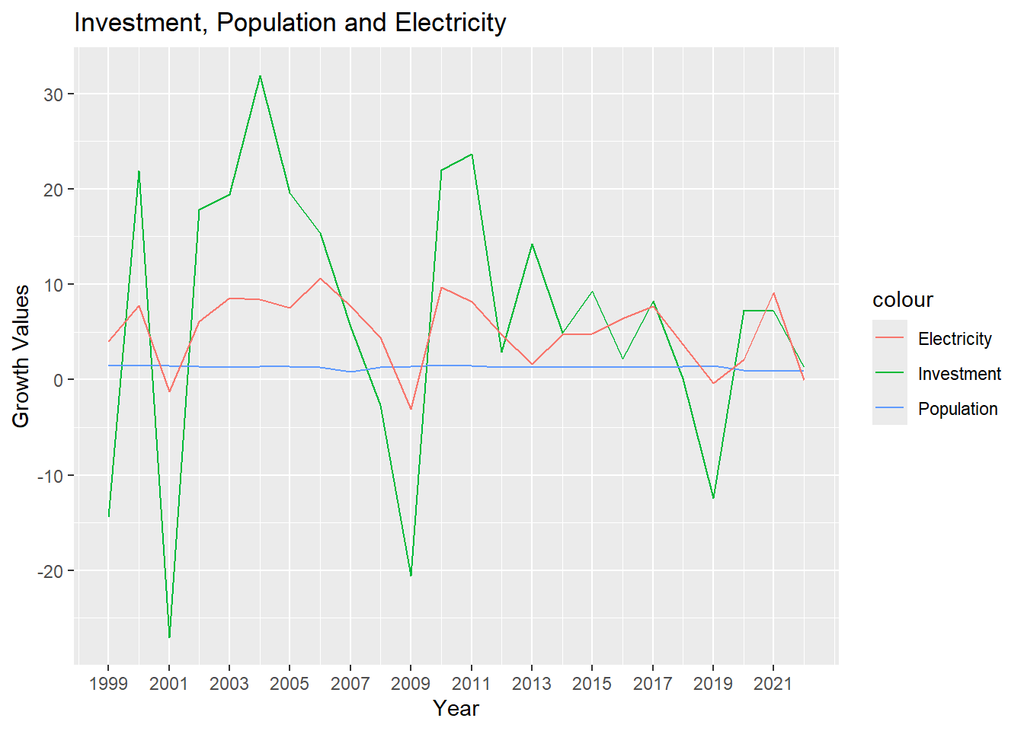

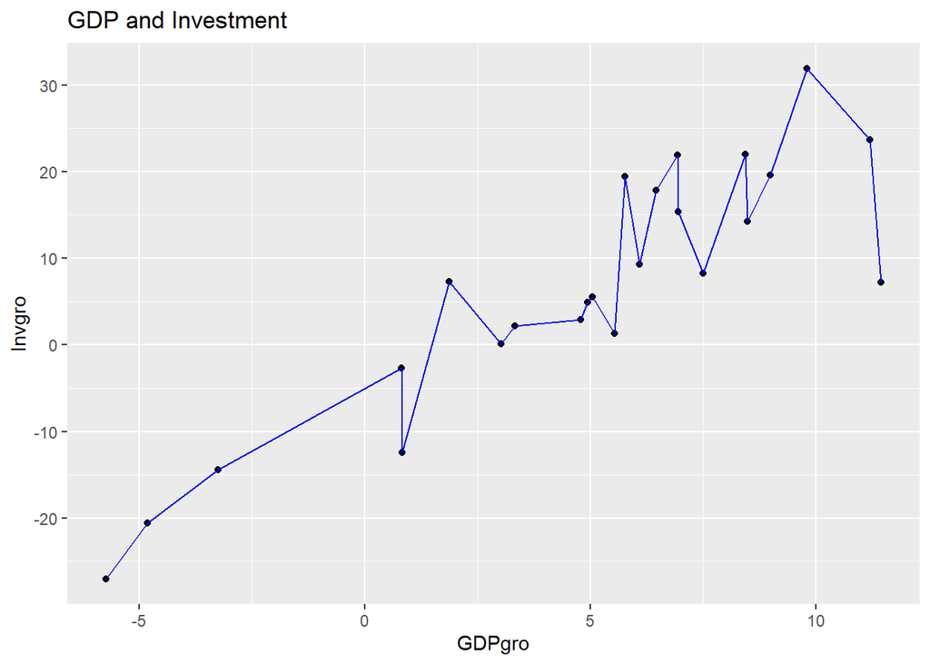

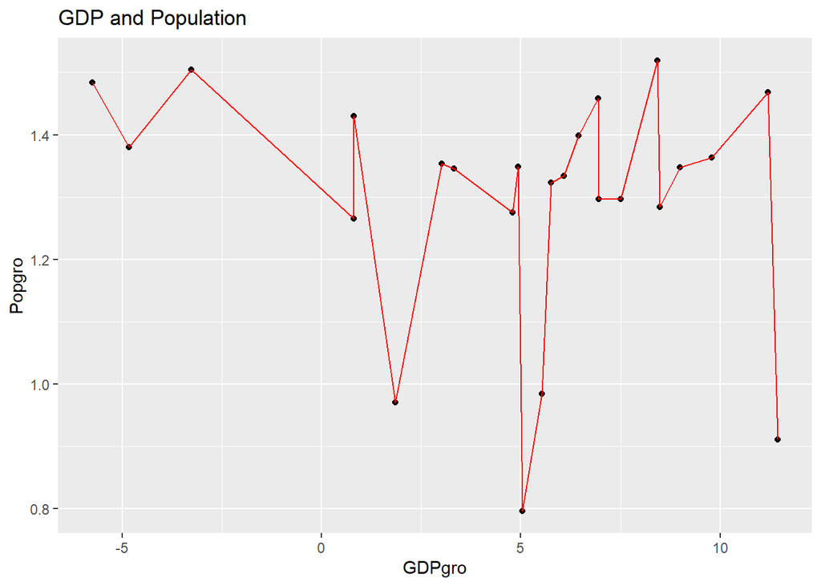

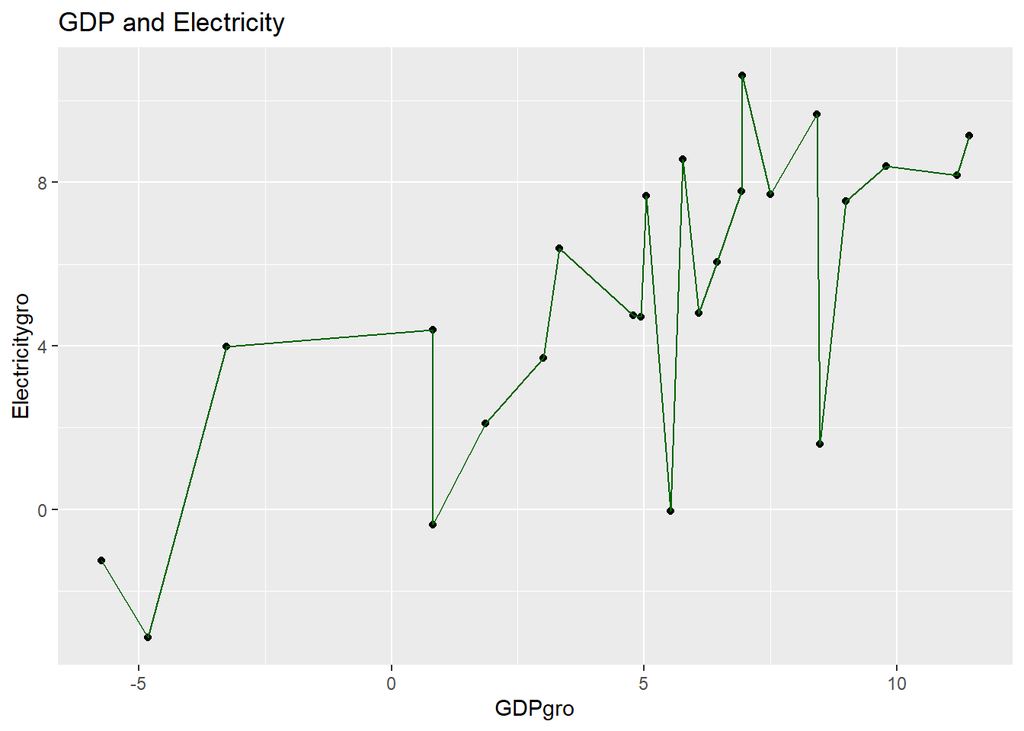

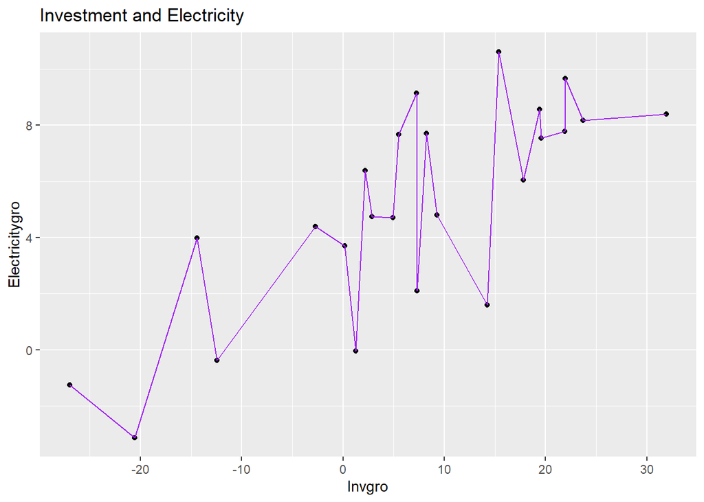

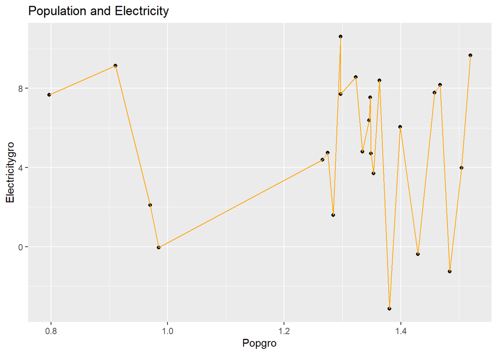

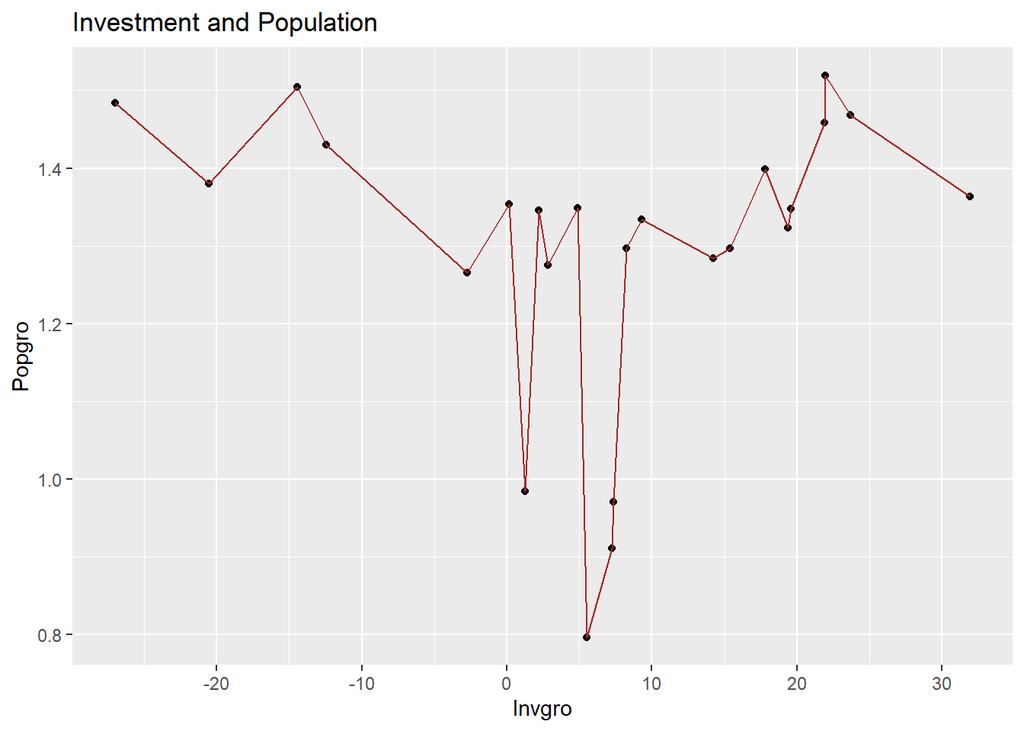

## Time Series Analysis

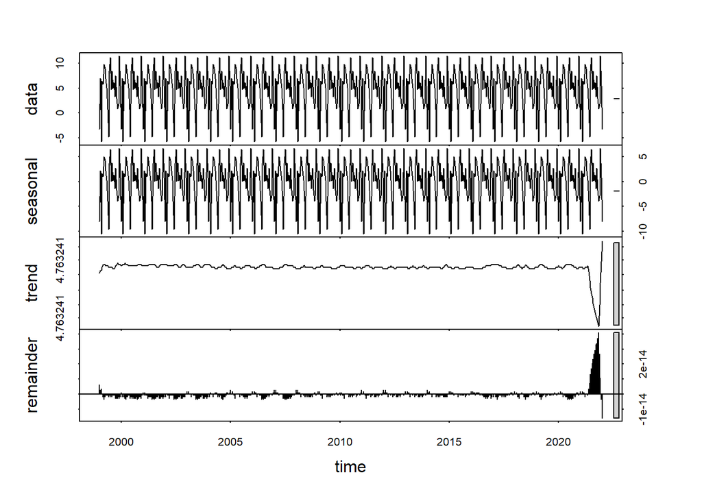

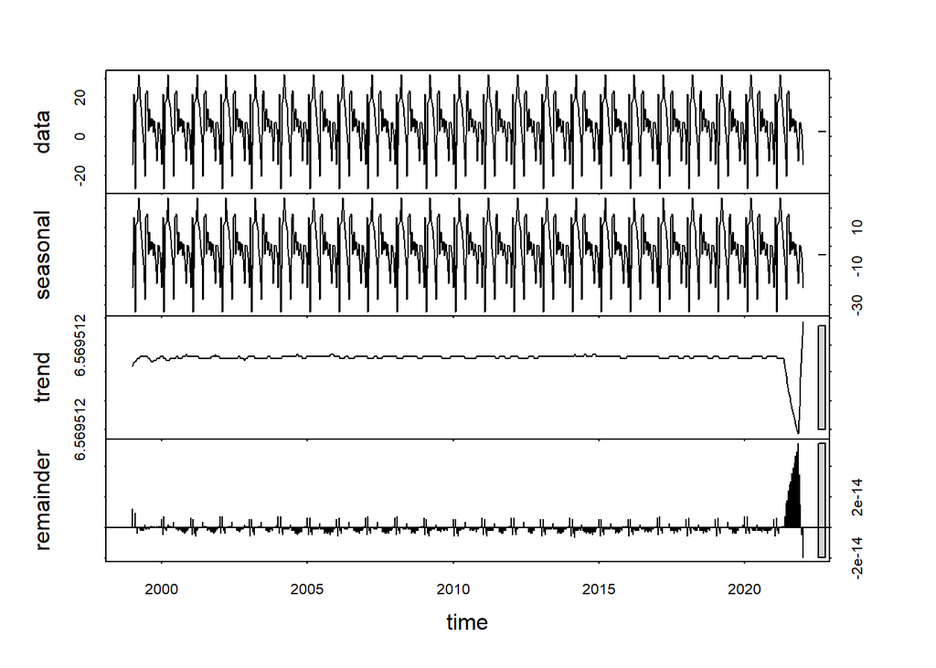

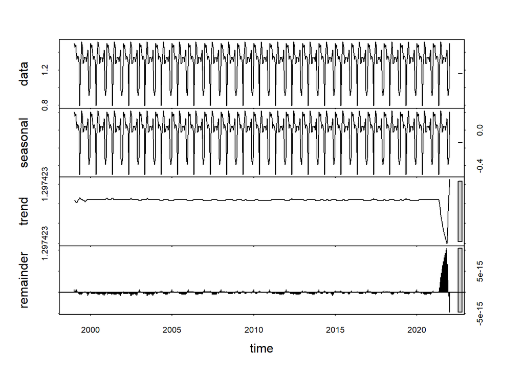

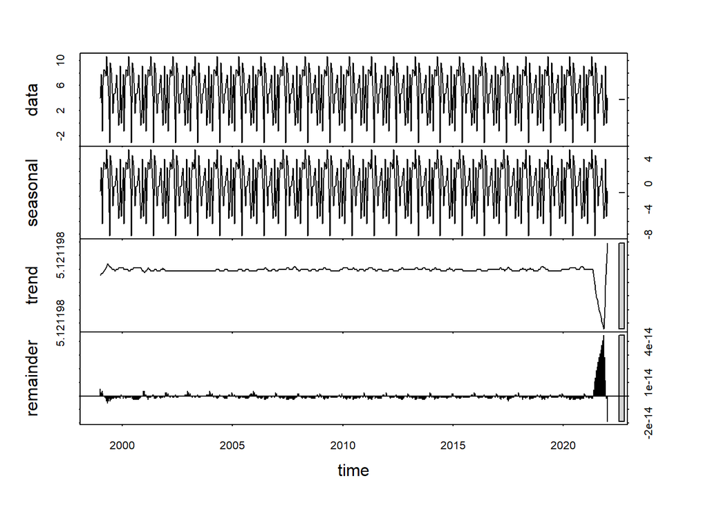

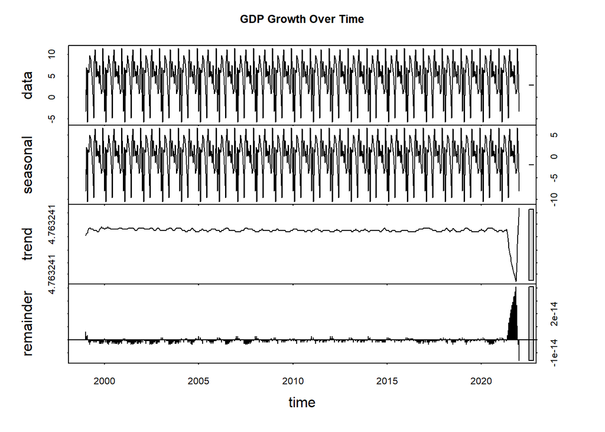

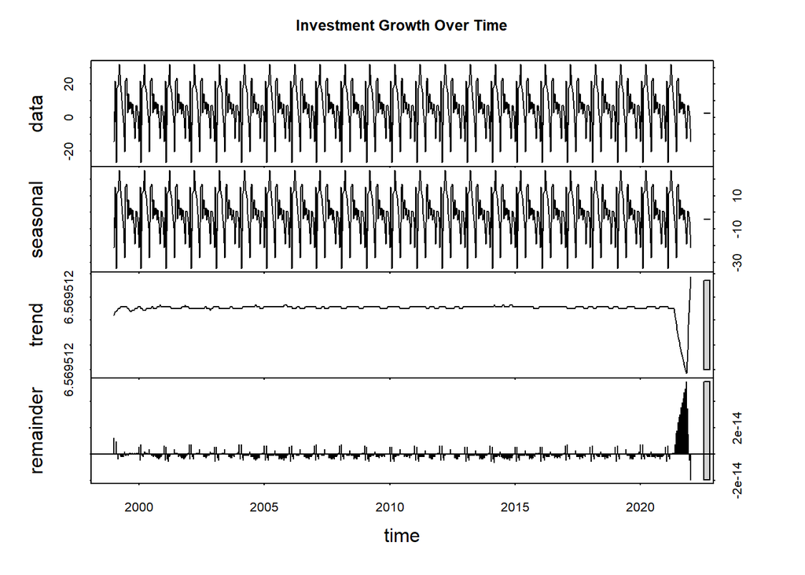

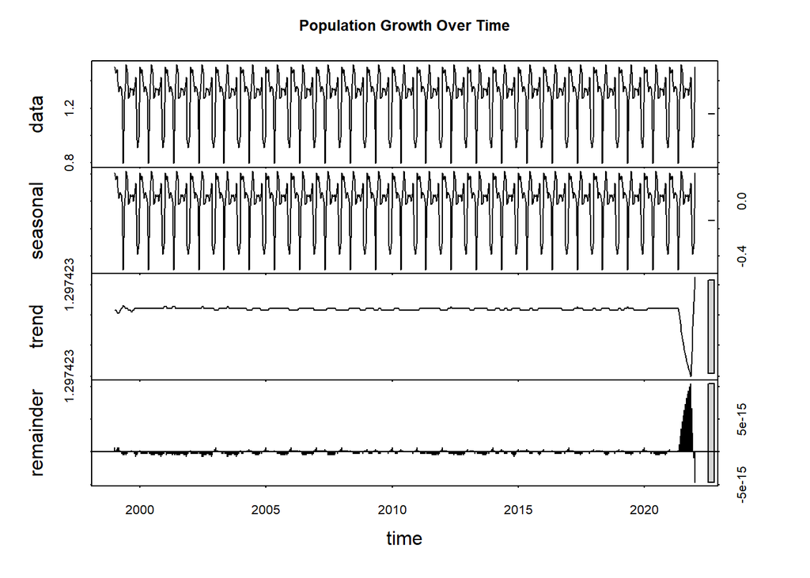

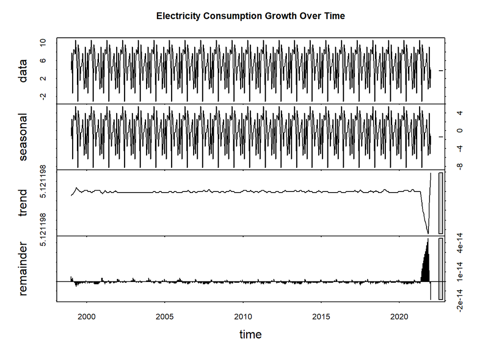